# Final Project- Electrical Consumption of the Smith College Campus

some Smith students

5/5/2015

```r
projectdata <- read.csv("group-F-data.csv")
projectdata2 <- read.csv("group-F-data-modified.csv")
require(mosaic)
```

**ABSTRACT**

With increasing concerns over the effects of climate change, coupled with rising operation costs, many U.S. colleges and universities are making an effort to improve their energy efficiency and sustainability. Smith College is one such institution, and while it has implemented an energy production method that greatly reduces its energy expenditures and improved its efficiency, there is always room for improvement. This study sought to examine possible patterns in energy use relating to three factors –weather, day of the week and student activity, which were then broken down into more specific subcategories– in order to provide a foundation for establishing further efficiency practices on campus. Using linear regression models and an ANOVA test, only one statistically significant relationship was found across 15 categories: there is a reduction in energy consumption associated with in-term and between-term vacations.

**INTRODUCTION AND BACKGROUND**

Many colleges in the U.S. are working toward using energy more efficiently and improving their sustainability practices.[1] This approach benefits schools in a variety of ways: helping to manage costs[2]; attracting incoming students –in a 2014 study by the Princeton Review, over half of the incoming freshman surveyed said that “environmental issues” would contribute to their “decision to apply or attend”)[3]; reducing consumption to safeguard energy security and mollify extreme cost spikes in an era when critical global energy sources are affected by political instability (i.e. Russia and The Middle East)[4]; making substantial contributions to reducing greenhouse gas emissions that lead to climate change[5].

Smith College has implemented many strategies to improve efficiency and sustainability, the most significant of which is the co-generation turbine power facility. The energy plant turns natural gas into electricity while harnessing thermal energy (which would typically go to waste) for heating and cooling purposes. Since the plant began operating in 2007, Smith College has increased its “energy use efficiency from 45%… to as much as 85%”[6], and it now provides almost all of the energy the campus requires during the academic year.

While these improvements are admirable, more can be done to improve the college’s energy efficiency. An important first step in creating more efficient practices is to understand patterns of energy use. There are many factors that might relate to energy consumption. Our study examines three such factors: weather, day of the week and student activities. Is there a correlation between energy consumption, weather, student activities (such as exams and vacations) and specific days of the week?

In this observational study, we looked at data for the year 2014 from the co-generation plant, the academic calendar and weather conditions on a day-to-day basis. We formed regression models to examine the data for significant relationships.

**DATA**

The data was obtained from the Smith College’s Chief Engineer Chuck Dougherty and included the amount of electricity generated and the amount of electricity exported to the grid (ISO New England) measured in megawatts (MW). Electrical consumption, the test statistic, was calculated by finding the difference between the amount of electricity generated each day and the amount “sold back” to the grid (the surplus).  
The initial models included test statistic data from days that the cogeneration plant did not generate enough electricity to meet the campus need. Data from such days could not be analyzed because consumption could not be calculated accurately. We did not have access for data on the electricity purchased from the grid on these days. These data points were removed from the dataset and a new data set was created, called projectdata2.

```r
head(projectdata2)
```

```
##       Date ElecGeneration ElecExport Consumption    Steam ExamWeek Holiday
## 1 1/1/2014           52.4      2.570      49.830 1,179.40       no      no
## 2 1/2/2014           68.0      7.477      60.523 1,529.40       no      no
## 3 1/3/2014           62.4     10.892      51.508 1,625.90       no      no
## 4 1/4/2014           53.1      2.971      50.129 1,425.30       no      no
## 5 1/5/2014           58.0      2.564      55.436 1,137.20       no      no
## 6 1/6/2014           62.6      2.615      59.985 1,237.10       no      no
##   Vacation Jterm Temperature Humidity Precipitation   Weekday Snowday
## 1      yes    no          21       10          0.00 Wednesday      no
## 2      yes    no          12       14          0.04  Thursday      no
## 3      yes    no           0        0          0.01    Friday      no
## 4      yes    no           4       -5          0.00  Saturday      no
## 5      yes    no          16       22          0.02    Sunday      no
## 6      yes   yes          40       37          1.05    Monday      no
```

The average daily electrical consumption of the campus based on the data provided was 60.6 MW. The averages of the numerical values are listed below. Also included are the averages for the categorical variables; ExamWeek, Vacation, JTerm, and Weekday. We excluded the variable Snowday because there was only one snow day to account for during this academic year. There is data for steam production included in the dataset, but we did not include this variable because it’s likely correlated with Electrical Generation and would therefore would violate the requirement for independence between variables.

```r
favstats(projectdata2$Consumption)
```

```
##    min     Q1 median     Q3   max   mean       sd   n missing
##  22.45 58.099 62.716 66.069 75.62 60.645 8.459424 229       0
```

```r
favstats(projectdata2$Temperature)
```

```
##  min Q1 median Q3 max     mean       sd   n missing
##    0 26     38 48  77 37.49782 15.44873 229       0
```

```r
favstats(projectdata2$Humidity)
```

```
##  min Q1 median Q3 max     mean       sd   n missing
##   -8 17     29 40  70 28.66812 17.03129 229       0
```

```r
favstats(projectdata2$Precipitation)
```

```
##  min Q1 median   Q3  max      mean        sd   n missing
##    0  0      0 0.07 1.78 0.1351965 0.3289265 229       0
```

```r
favstats(projectdata2$Consumption ~ projectdata2$Weekday)
```

```
##      .group    min      Q1  median      Q3    max     mean        sd  n
## 1    Friday 34.266 60.1830 62.7525 64.0120 72.285 60.69388  6.623694 34
## 2    Monday 25.403 59.4955 63.9060 67.9670 72.731 60.59268 11.003810 31
## 3  Saturday 24.937 54.4075 57.7990 60.7300 68.152 56.62397  7.430094 34
## 4    Sunday 30.408 56.5110 61.9360 63.9310 69.236 59.46118  7.299376 33
## 5  Thursday 48.319 60.7270 64.5920 66.4410 72.550 63.27273  5.210689 33
## 6   Tuesday 24.000 62.1450 65.1980 68.0425 70.800 62.27458  9.626848 31
## 7 Wednesday 22.450 60.0150 63.7840 67.3680 75.620 61.81197  9.856109 33
##   missing
## 1       0
## 2       0
## 3       0
## 4       0
## 5       0
## 6       0
## 7       0
```

```r
favstats(projectdata2$Consumption ~ projectdata2$ExamWeek)
```

```
##   .group    min      Q1 median     Q3    max     mean       sd   n missing
## 1     no 22.450 57.5665 62.921 66.401 75.620 60.75691 8.490043 215       0
## 2    yes 34.126 59.8265 61.814 62.796 64.342 58.92650 8.070685  14       0
```

```r
favstats(projectdata2$Consumption ~ projectdata2$Vacation)
```

```
##   .group    min       Q1 median       Q3    max     mean      sd   n
## 1     no 22.450 60.99800 64.039 67.00300 75.620 62.35055 8.67278 165
## 2    yes 34.266 52.12375 56.521 60.54125 68.004 56.24791 5.99355  64
##   missing
## 1       0
## 2       0
```

```r
favstats(projectdata2$Consumption ~ projectdata2$Jterm)
```

```
##   .group    min      Q1 median       Q3    max     mean       sd   n
## 1     no 22.450 58.1145 63.325 66.43375 75.620 60.80159 8.773441 210
## 2    yes 49.935 57.3525 59.985 60.88900 62.185 58.91437 3.042613  19
##   missing
## 1       0
## 2       0
```

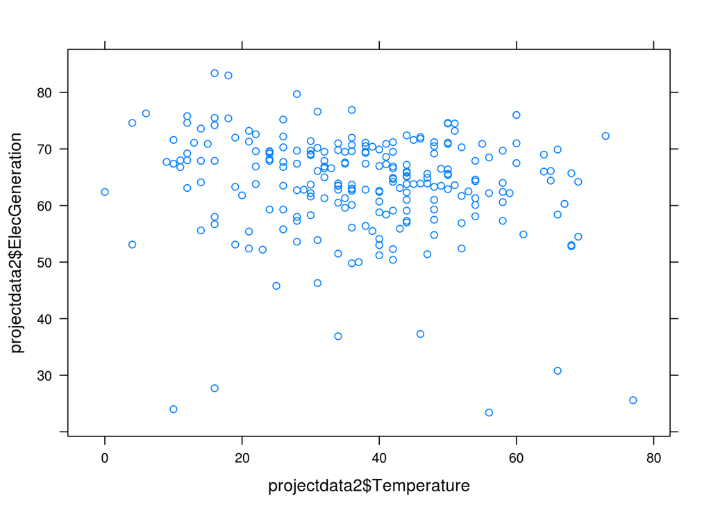

```r
xyplot(projectdata2$ElecGeneration ~ projectdata2$Temperature)
```

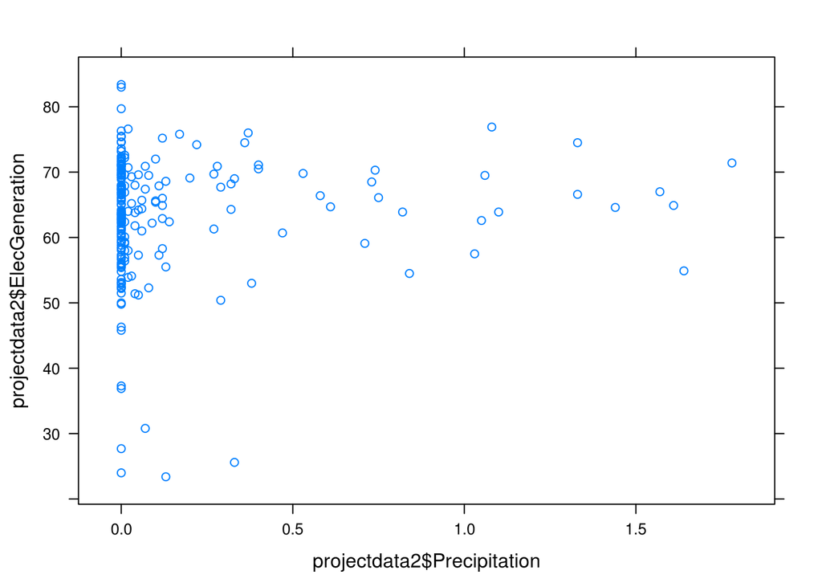

```r
xyplot(projectdata2$ElecGeneration ~ projectdata2$Precipitation)
```

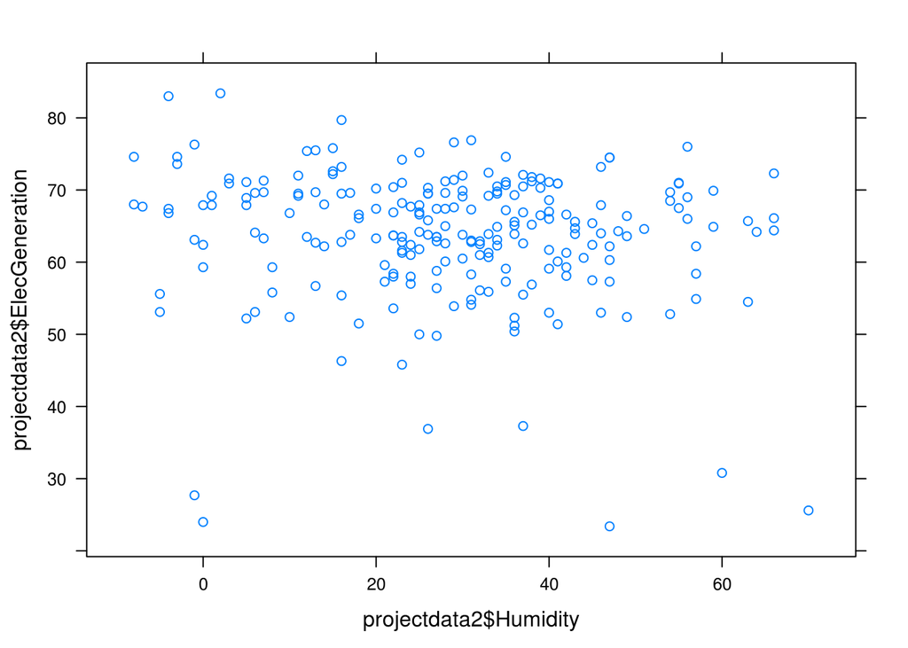

```r
xyplot(projectdata2$ElecGeneration ~ projectdata2$Humidity)
```

**RESULTS**

The data was modeled using a multiple linear regression model, where Electrical Consumption was the response variable. The initial model was based off of the initial dataset that included days the cogeneration plant was not self-sufficient, and thus was not valid.

```r
model <- lm(Consumption ~ ExamWeek + Holiday + Vacation + Jterm + Temperature + Humidity + Precipitation + Weekday + Snowday, data=projectdata)
summary(model)
```

```
##
## Call:
## lm(formula = Consumption ~ ExamWeek + Holiday + Vacation + Jterm +
##     Temperature + Humidity + Precipitation + Weekday + Snowday,
##     data = projectdata)
##
## Residuals:
##     Min      1Q  Median      3Q     Max
## -67.131  -7.735   5.449  12.792  40.491
##
## Coefficients:
##                  Estimate Std. Error t value Pr(>|t|)
## (Intercept)       68.9505     4.7243  14.595  < 2e-16 ***
## ExamWeekyes        4.7046     5.8211   0.808 0.419531
## Holidayyes        10.4523    15.8054   0.661 0.508847
## Vacationyes      -10.2389     2.7246  -3.758 0.000201 ***
## Jtermyes           9.1736     5.7887   1.585 0.113927
## Temperature       -0.2088     0.2388  -0.874 0.382708
## Humidity          -0.3049     0.2277  -1.339 0.181463
## Precipitation     10.7015     3.6524   2.930 0.003612 **
## WeekdayMonday     -1.0104     4.3095  -0.234 0.814767
## WeekdaySaturday   -1.2450     4.2661  -0.292 0.770580
## WeekdaySunday      0.5969     4.2797   0.139 0.889159
## WeekdayThursday    0.8149     4.2983   0.190 0.849740
## WeekdayTuesday     5.0373     4.2684   1.180 0.238743
## WeekdayWednesday   2.1524     4.3187   0.498 0.618530
## Snowdayyes        -0.6890    22.0363  -0.031 0.975073
## ---
## Signif. codes:  0 '***' 0.001 '**' 0.01 '*' 0.05 '.' 0.1 ' ' 1
##
## Residual standard error: 21.69 on 350 degrees of freedom
## Multiple R-squared:  0.284,  Adjusted R-squared:  0.2554
## F-statistic: 9.918 on 14 and 350 DF,  p-value: < 2.2e-16
```

The invalid linear model above only has 2 variables with p-values below the 0.05 threshold: vacation and precipitation. All of the other p-values are high and a new model would have to be fit examining only p-values below the 0.05 threshold, using backwards elimination.

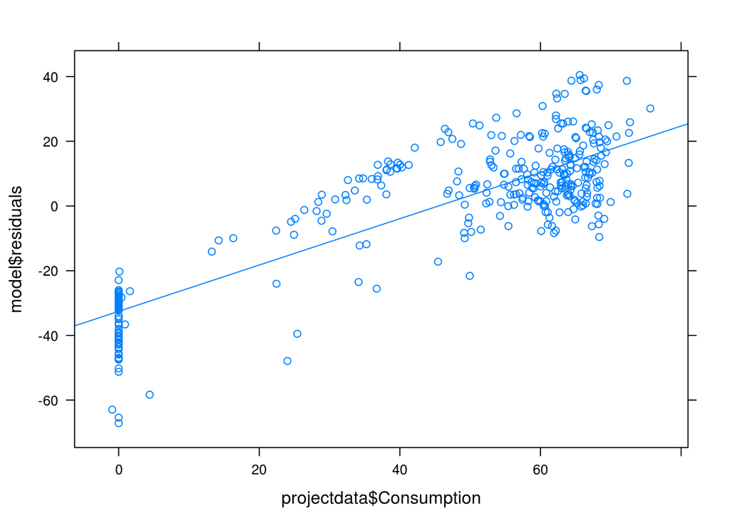

```r
xyplot(model$residuals ~ projectdata$Consumption,type=c("p","r"))
```

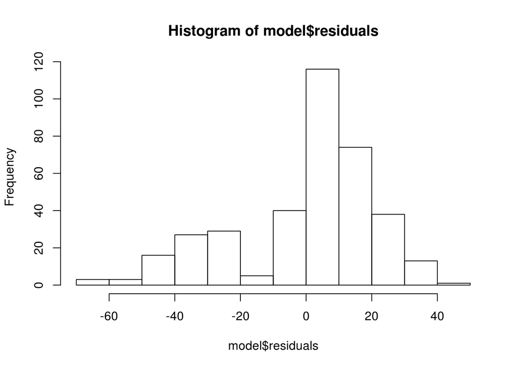

```r
hist(model$residuals)
```

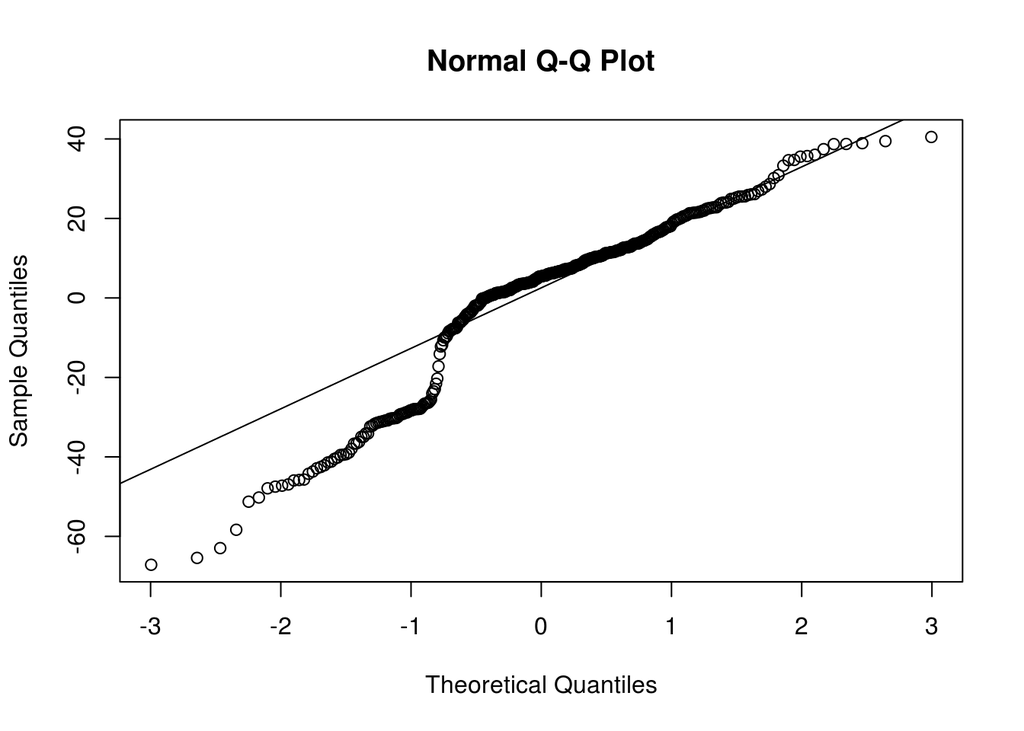

```r
qqnorm(model$residuals)
qqline(model$residuals)
```

After determining that this model did not pass the conditions for linear regression (the variance was not constant and the data was not normal) and that the data was not valid, a new model was created with the modified data set, examining only days that the cogeneration plant was self-sufficient for the Smith campus (when demand did not exceed generation).

```r
projectdata2 <- read.csv("group-F-data-modified.csv")
model3 <- lm(Consumption ~ ExamWeek + Holiday + Vacation + Jterm + Temperature + Humidity + Precipitation + Weekday + Snowday, data=projectdata2)
summary(model3)
```

```
##
## Call:
## lm(formula = Consumption ~ ExamWeek + Holiday + Vacation + Jterm +
##     Temperature + Humidity + Precipitation + Weekday + Snowday,
##     data = projectdata2)
##
## Residuals:
##     Min      1Q  Median      3Q     Max
## -41.047  -1.063   1.315   3.224  11.555
##
## Coefficients:
##                  Estimate Std. Error t value Pr(>|t|)
## (Intercept)      62.35521    2.07240  30.088  < 2e-16 ***
## ExamWeekyes      -2.83600    2.22091  -1.277    0.203
## Holidayyes        3.30458    5.81306   0.568    0.570
## Vacationyes      -6.99171    1.34813  -5.186 4.96e-07 ***
## Jtermyes          3.16714    2.21202   1.432    0.154
## Temperature      -0.01661    0.09983  -0.166    0.868
## Humidity          0.02336    0.09354   0.250    0.803
## Precipitation     1.76655    1.85462   0.953    0.342
## WeekdayMonday    -0.24005    1.99929  -0.120    0.905
## WeekdaySaturday  -3.98875    1.95016  -2.045    0.042 *
## WeekdaySunday    -0.92961    1.94552  -0.478    0.633
## WeekdayThursday   2.21538    1.97270   1.123    0.263
## WeekdayTuesday    1.42610    1.98477   0.719    0.473
## WeekdayWednesday  0.74474    1.96836   0.378    0.706
## Snowdayyes       -4.79643    8.08479  -0.593    0.554
## ---
## Signif. codes:  0 '***' 0.001 '**' 0.01 '*' 0.05 '.' 0.1 ' ' 1
##
## Residual standard error: 7.9 on 214 degrees of freedom
## Multiple R-squared:  0.1814, Adjusted R-squared:  0.1278
## F-statistic: 3.387 on 14 and 214 DF,  p-value: 5.911e-05
```

The new model had two variables with p-values below the 0.05 threshold: weekday (when equal to Saturday, referenced against Friday), and vacation. After backwards elimination, a new model was generated using these two parameters. The model was then tested to see if it fulfilled the conditions for linear regression.

```r
model5 <- lm(Consumption ~ Vacation + Weekday, data=projectdata2)
summary(model5)
```

```
##
## Call:
## lm(formula = Consumption ~ Vacation + Weekday, data = projectdata2)
##
## Residuals:
##     Min      1Q  Median      3Q     Max
## -40.973  -1.154   1.664   3.691  12.197
##
## Coefficients:
##                  Estimate Std. Error t value Pr(>|t|)
## (Intercept)       62.2580     1.3879  44.858  < 2e-16 ***
## Vacationyes       -5.9089     1.1640  -5.077 8.15e-07 ***
## WeekdayMonday     -0.1404     1.9596  -0.072   0.9429
## WeekdaySaturday   -3.7223     1.9150  -1.944   0.0532 .
## WeekdaySunday     -1.0062     1.9287  -0.522   0.6024
## WeekdayThursday    2.4472     1.9284   1.269   0.2058
## WeekdayTuesday     1.7321     1.9598   0.884   0.3778
## WeekdayWednesday   1.1655     1.9282   0.604   0.5462
## ---
## Signif. codes:  0 '***' 0.001 '**' 0.01 '*' 0.05 '.' 0.1 ' ' 1
##
## Residual standard error: 7.891 on 221 degrees of freedom
## Multiple R-squared:  0.1566, Adjusted R-squared:  0.1299
## F-statistic: 5.864 on 7 and 221 DF,  p-value: 2.938e-06
```

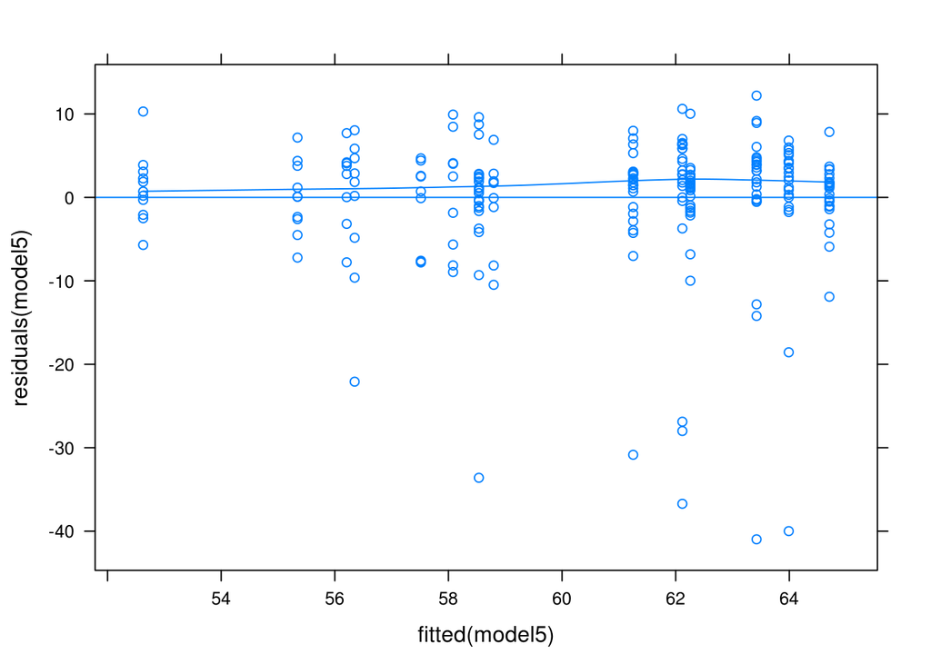

```r
xyplot(residuals(model5) ~ fitted(model5), type=c("p", "r", "smooth"))
```

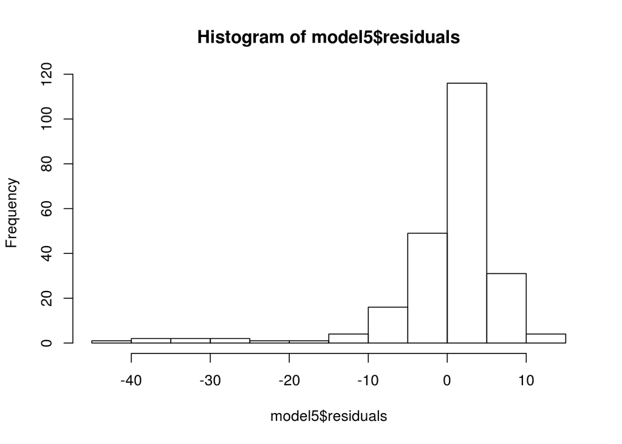

```r
hist(model5$residuals)
```

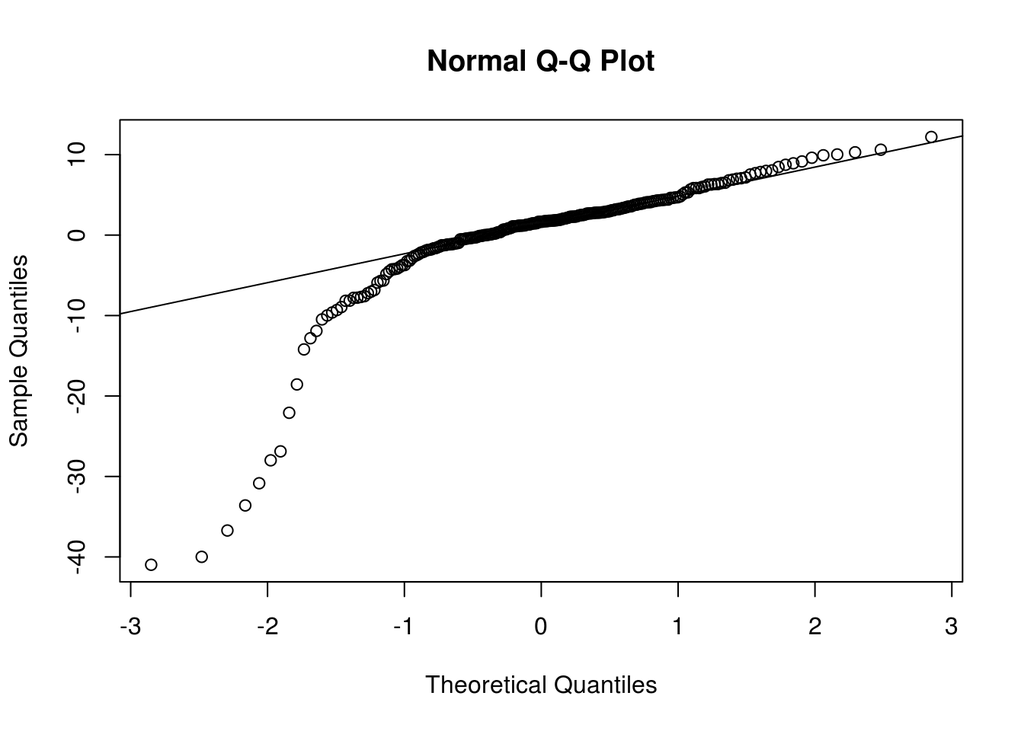

```r
qqnorm(model5$residuals)
qqline(model5$residuals)
```

Since the data could not be modeled using linear regression, the categorical variables Vacation and Weekday were examined.

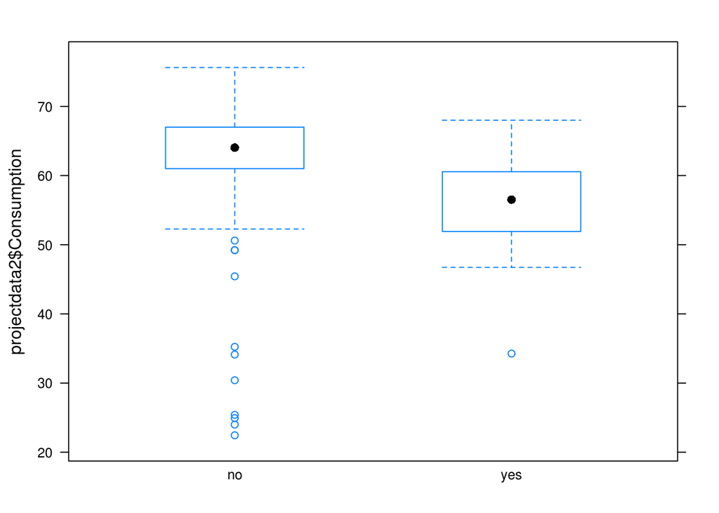

```r
bwplot(projectdata2$Consumption ~ projectdata2$Vacation)
```

```r
t.test(projectdata2$Consumption ~ projectdata2$Vacation)
```

```
##
##  Welch Two Sample t-test
##
## data:  projectdata2$Consumption by projectdata2$Vacation
## t = 6.051, df = 165.063, p-value = 9.357e-09
## alternative hypothesis: true difference in means is not equal to 0
## 95 percent confidence interval:
##  4.111338 8.093941
## sample estimates:
##  mean in group no mean in group yes
##          62.35055          56.24791
```

The following hypothesis tests were used to examine the categorical variable Vacation:

H0: The true difference of the means is equal to 0

HA: The true difference of the means is not equal to 0

Based on the t-test, there is a statistically significant difference between vacation days and non-vacation days. H0 is rejected in favor of HA, since a mean of 0 does not fall into the confidence interval [4.11, 8.09]. The differences in the means cannot be explained by chance.

Thus…

On average, the campus consumes more electricity on non-vacation days.

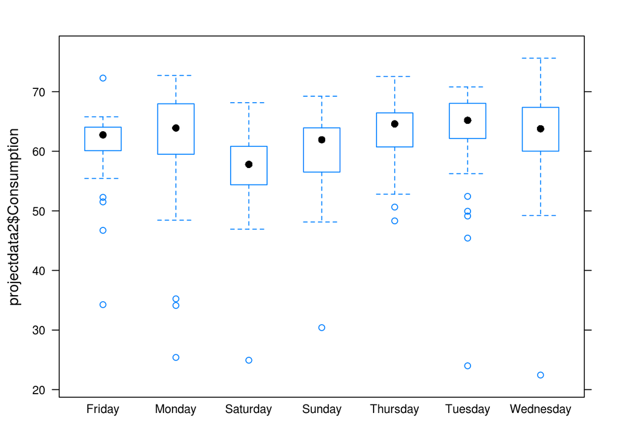

```r
bwplot(projectdata2$Consumption ~ projectdata2$Weekday)
```

```r
anovatest <- aov(projectdata2$Consumption ~ projectdata2$Weekday)
summary(anovatest)
```

```
##                       Df Sum Sq Mean Sq F value Pr(>F)
## projectdata2$Weekday   6    951  158.55   2.291 0.0364 *
## Residuals            222  15365   69.21
## ---
## Signif. codes:  0 '***' 0.001 '**' 0.01 '*' 0.05 '.' 0.1 ' ' 1
```

Using a significance level of 0.05, at least one mean for the variable weekday is different. However, after accounting for Bonferroni’s correction on the significance level (0.00238 for 6 degrees of freedom), the p-value is not within the threshold and it can be concluded that there is no statistically significant difference in the weekday variable, though there is slight variation in the plot. A statistically significant relationship was found between Consumption and Vacation, but not between Consumption and any of the other variables examined.

**CONCLUSION**

Our research looked for correlations between energy consumption at Smith College and three factors that might influence consumption amounts –weather, student activities and day of the week– using linear regression models and an ANOVA test. Each successive regression model was adjusted to address issues with the previous model –removing statistically insignificant relationships and from the analysis and data that did not provide relevant information.  
Despite efforts to improve the models, conditions for regression were not met and only one statistically significant relationship was found: there is a negative correlation between energy consumption and vacation days. In other words, Smith College Campus uses less energy when students are on break. While this finding is reasonable, it does not provide helpful information for further improving Smith College’s energy efficiency and sustainability as we had hoped.  
There may be confounding variables for which we did not account, such as events at the conference center, January graduation and other activities that might affect energy consumption. The fact that we could not find a direct relationship between temperature and energy consumption, a correlation that very likely exists but did not appear in our analysis, supports the suspicion that there is a mitigating influence at work. Further investigation of these topics may include some improvements to our data gathering, such as gaining access to data for the days on which Smith bought power form the grid, data on other types of students activities (sporting events, political rallies, orientation days, etc.), or subcategories of energy consumption by campus building.

**REFERENCES**

[1] http://www.ed.gov/blog/2013/01/colleges-and-universities-lead-the-way-in-sustainability/ [2] https://www.nationalgridus.com/non_html/shared_energyeff_college.pdf [3] http://www.theguardian.com/sustainable-business/2014/jul/22/green-colleges-students-decisions-environment [4] http://www.iea.org/topics/energysecurity/ [5] http://www.presidentsclimatecommitment.org/about/commitment [6] http://www.smith.edu/green/cogen.php C. Dougherty, personal communication, February 4, 2015).